# BAT RNA-seq Analysis

Stefan Tholen, Kyle M. Kovary, Mary N. Teruel

Updated: 2019-05-13 12:28:19

### Introduction

This is a notebook to document the analysis of the RNA-seq data collected by Stefan from brown adipose tissue in mice that were treated with corticosterone pellet or injections to compare to sham pellet or injections over the course of 14 days. This is still in development, eventually I plan have the data analysis pipeline with quality control and analysis plots as well as the code used to analyze everything.

```r
knitr::opts_chunk$set(echo = TRUE, message = FALSE, warning = FALSE)
library(tidyverse)
library(sleuth)
library(DESeq2)
library(readxl)
library(pheatmap)
library(RColorBrewer)
library(kableExtra)
library(eulerr)
```

### Metadata Import

```r
sample_list = read_xlsx('/Users/kylekovary/Box Sync/kkovary/R Projects/RNAseq/Stefan RNA-seq BAT analysis/Stefan Tholen_Samples_for_RNAseq_BAT.xlsx')

# Set up metadata table
path = list.dirs('/Users/kylekovary/Box Sync/kkovary/R Projects/RNAseq/Stefan RNA-seq BAT analysis/kallisto_output/')[-c(1,2)]
path = path %>% as.tibble() %>%
  separate(col = value, into = c('a','mouse'), sep = 'ST-', remove = F) %>%
  dplyr::select(value, mouse)

s2c = bind_cols(sample_list, path[match(sample_list$mouse, path$mouse),1]) %>%
  dplyr::rename(path = value, sample_name = `Sample Name`, Pellet = Treatment) %>%
  unite('Treatment',c('Pellet','Delivery'), remove = F)
```

### Data Import

```r
# Retrieve GeneNames
library(biomaRt)
tx2gene <- function(){
  mart <- biomaRt::useMart(biomart = "ensembl", dataset = "mmusculus_gene_ensembl")
  t2g <- biomaRt::getBM(attributes = c("ensembl_transcript_id", "ensembl_gene_id",
                                       "external_gene_name","entrezgene"), mart = mart)
  t2g <- dplyr::rename(t2g, target_id = ensembl_transcript_id,
                       ens_gene = ensembl_gene_id, ext_gene = external_gene_name)
  return(t2g)
}
t2g <- tx2gene()

so <- sleuth_prep(s2c, target_mapping = t2g, num_cores = max(1L, parallel::detectCores() - 1L), extra_bootstrap_summary = TRUE)

sleuth_save(so, '/Users/kylekovary/Box Sync/kkovary/R Projects/RNAseq/Stefan RNA-seq BAT analysis/so')
```

### DESeq2 Model

```r
so <- sleuth_load('/Users/kylekovary/Box Sync/kkovary/R Projects/RNAseq/Stefan RNA-seq BAT analysis/so')

full_design <- model.matrix(formula(~ s2c$Treatment + s2c$lane + s2c$Replicate, s2c$Day))

so <- sleuth_fit(so, full_design, 'full')
so <- sleuth_fit(so, formula = ~ s2c$lane + s2c$Replicate, fit_name = "reduced")
so <- sleuth_lrt(so, "reduced", "full")

#plot_qq(so, test = 'reduced:full', test_type = 'lrt', sig_level = 0.05)

lrt_results <- sleuth_results(so, 'reduced:full', test_type = 'lrt')
table(lrt_results[,"qval"] < 0.05)
```

```
##
## FALSE  TRUE
## 33984  4019
```

### Select Differentially Expressed Genes

```r
hits = filter(lrt_results, qval < 0.05)
hits_dat = so$obs_norm_filt %>% dplyr::select(target_id, sample, est_counts) %>% filter(target_id %in% hits$target_id) %>% spread(key = sample, value = est_counts)
genes = hits_dat$target_id
genes = hits[match(genes,hits$target_id),'ext_gene']
hits_dat = as.matrix(hits_dat[,2:ncol(hits_dat)])
rownames(hits_dat) = genes

zeros = which(hits_dat <= 0, arr.ind = T)
for(i in 1:nrow(zeros)){
  hits_dat[zeros[i,1], zeros[i,2]] = 1
}
```

### Heatmap of Differentially Expressed Genes

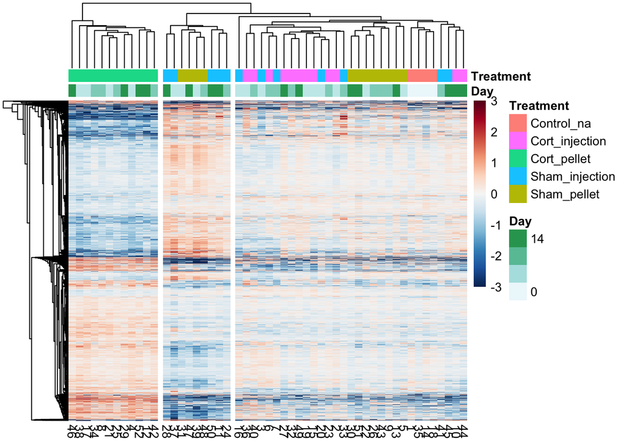

```r
hits_dat = t(apply(hits_dat, 1, function(x) x / mean(x)))

annotation = dplyr::select(s2c, Day, Treatment) %>% as.data.frame()
rownames(annotation) <- s2c$sample

mypal = rev(colorRampPalette(brewer.pal(11, "RdBu"))(n=200))

pheatmap(log2(hits_dat), breaks = seq(-3,3,6/(length(mypal))),
         color = mypal,
         show_rownames = F,
         show_colnames = T,
         annotation_col = annotation,
         cutree_cols = 3)
```

These samples are 28, 37, 31, 47, 39, 48, 50, 11, 24.

```r
outliers = filter(s2c, sample %in% c(28, 37, 31, 47, 39, 48, 50, 11, 24)) %>%
  dplyr::select(sample, Pellet, Delivery, Day, Replicate) %>%
  data.table::setorder(Delivery, Day, Replicate) %>% dplyr::rename(`Sample #` = sample, Condition = Pellet)

knitr::kable(outliers, row.names = F) %>% kable_styling()
```

| Sample # | Condition | Delivery | Day | Replicate |
| --- | --- | --- | --- | --- |
| 37 | Sham | injection | 3 | 4 |
| 24 | Sham | injection | 7 | 2 |
| 11 | Sham | injection | 14 | 1 |
| 28 | Sham | injection | 14 | 2 |
| 50 | Sham | injection | 14 | 4 |
| 31 | Sham | pellet | 3 | 3 |
| 39 | Sham | pellet | 3 | 4 |
| 48 | Sham | pellet | 7 | 4 |
| 47 | Sham | pellet | 14 | 3 |

### PCA of Differentially Expressed Genes

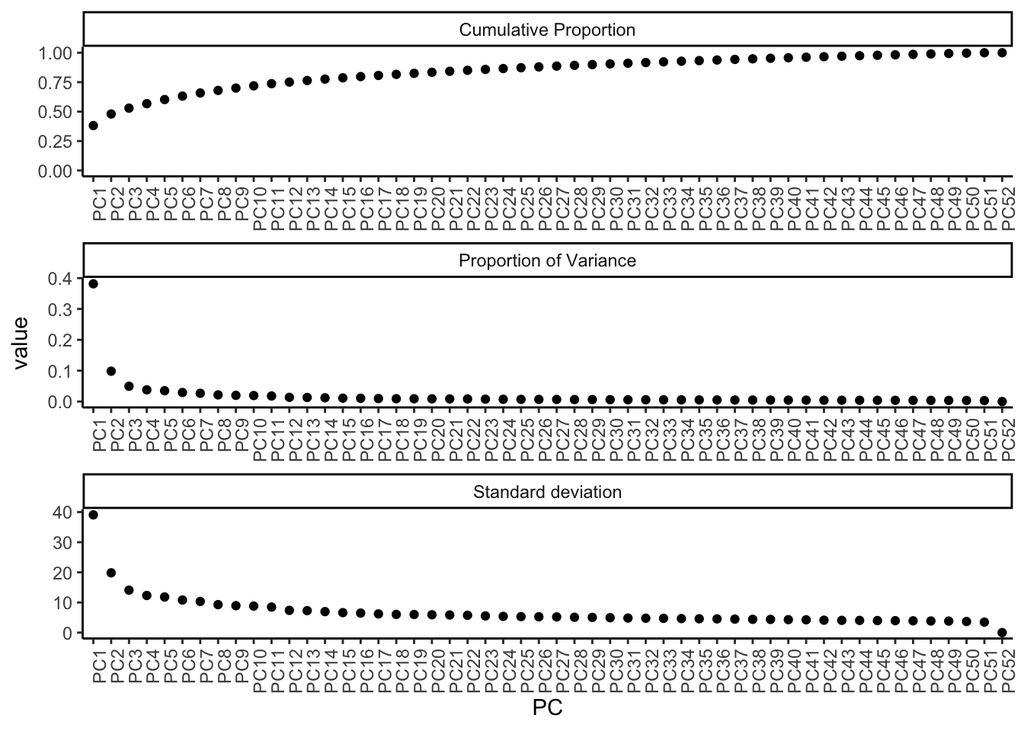

```r
pca = prcomp(t(hits_dat), center = T, scale. = T)

pcaSum = summary(pca)$importance %>% t() %>% as.data.frame() %>% mutate(PC = rownames(.)) %>%
  gather(key = plot, value = value, 1:3)
pcaSum$PC <- factor(pcaSum$PC, levels = paste0('PC',1:ncol(hits_dat)))

ggplot(pcaSum, aes(x = PC, y = value)) + geom_point() +
  facet_wrap(~plot, scales = 'free', ncol = 1) + theme_classic() +
  theme(axis.text.x = element_text(angle = 90, hjust = 1)) + ylim(0, NA)
```

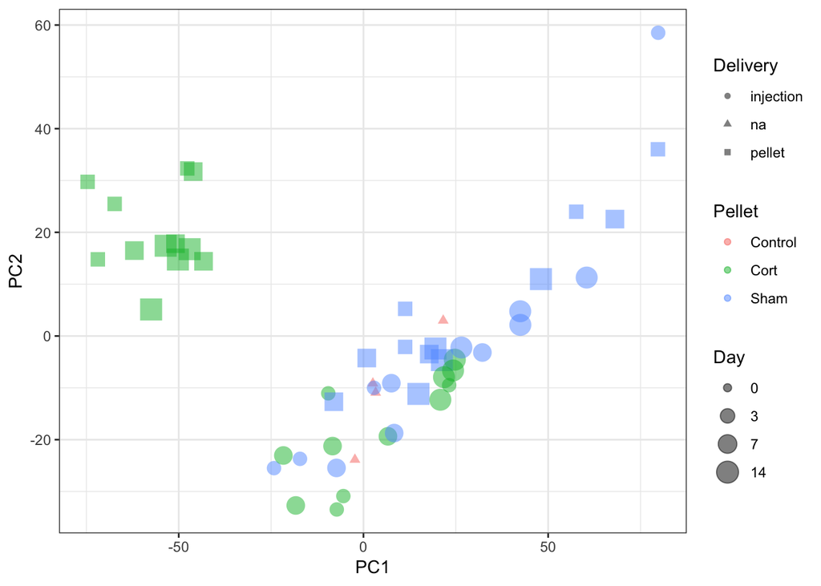

```r
pcaDF = tibble(sample = as.numeric(rownames(pca$x)), PC1 = pca$x[,1], PC2 = pca$x[,2])
pcaDF = full_join(pcaDF, s2c, by = 'sample') %>% mutate(Day = as.factor(Day))
pcaDF = pcaDF %>% mutate(outlier = ifelse(sample %in% c(28, 37, 31, 47, 39, 48, 50, 11, 24), T, F))

# 2D PCA between PC1 and PC2
ggplot(pcaDF, aes(x = PC1, y = PC2, colour = Pellet, size = Day, shape = Delivery)) + geom_point(alpha = 0.5) + theme_bw()
```